# Informe de las tres casos Actualización de Creencias con Nueva Evidencia

Estalyn Duchi

2026-03-26

# Resumen

El presente estudio analiza la aplicación del teorema de Bayes en la actualización de probabilidades bajo incertidumbre en tres contextos: diagnóstico médico, control de calidad y toma de decisiones empresariales. Se demuestra que la incorporación de nueva evidencia permite mejorar significativamente la precisión de las inferencias y optimizar decisiones. Asimismo, se evalúa el valor económico de la información mediante indicadores como el Valor Esperado de la Información Perfecta (VEIP) y el Valor Esperado de la Información Imperfecta (VEII).

**Palabras clave**: inferencia bayesiana, toma de decisiones, incertidumbre, valor esperado, probabilidad.

# Introducción

La teoría bayesiana permite actualizar probabilidades iniciales (a priori) cuando se dispone de nueva evidencia, generando probabilidades posteriores más precisas. Este enfoque es ampliamente utilizado en contextos médicos, industriales y empresariales para mejorar la toma de decisiones bajo incertidumbre.

En el presente informe se analizan tres casos aplicados: diagnóstico médico, control de calidad y toma de decisiones empresariales, integrando el enfoque bayesiano con criterios de valor esperado.

# Metodología

Se utilizó el enfoque bayesiano para actualizar probabilidades a partir de evidencia observada. Además, en el tercer caso se incorporaron criterios de decisión basados en:

Valor Monetario Esperado (VME)

Valor Esperado de Información Perfecta (VEIP)

Valor Esperado de Información Imperfecta (VEII)

## Caso Nª 1

```r
# ====================================================
# BAYES — Caso 1: Diagnóstico Médico
# ====================================================

# Datos del problema
prevalencia  <- 0.01   # Prior: 1% de la población tiene cáncer
sensibilidad <- 0.80   # P(Positivo | Cáncer)
falso_pos    <- 0.096  # P(Positivo | No Cáncer)
```

**Empezamos adra formarto a la tabla de contigencia**

Creamos un vector de probabilidades a priori (antes de ver la evidencia).

Define las verosimilitudes, es decir, probabilidades condicionales de observar la evidencia.

```r
# Tabla Bayesiana
estados <- c("Cáncer", "No Cáncer")
prior   <- c(prevalencia, 1 - prevalencia)
likel   <- c(sensibilidad, falso_pos)   # P(Positivo | estado)

# Paso 1-3: conjuntas
conjunta <- prior * likel

# Paso 4: probabilidad marginal de la evidencia
P_positivo <- sum(conjunta)
cat("P(Positivo) =", round(P_positivo, 4), "\n")
```

```
## P(Positivo) = 0.103
```

```r
# Paso 5: posteriors
posterior <- conjunta / P_positivo
```

**Podemos visualizar la tabla ya constrida**

```r
# Tabla completa
tabla <- data.frame(
  Estado      = estados,
  Prior       = prior,
  Verosimil   = likel,
  Conjunta    = conjunta,
  Posterior   = round(posterior, 4)
)
print(tabla)
```

```
##      Estado Prior Verosimil Conjunta Posterior
## 1    Cáncer  0.01     0.800  0.00800    0.0776
## 2 No Cáncer  0.99     0.096  0.09504    0.9224
```

```r
cat("\n→ P(Cáncer | Positivo) =", round(posterior[1] * 100, 1), "%\n")
```

```
##
## → P(Cáncer | Positivo) = 7.8 %
```

```r
cat("→ Aunque la prueba es positiva, solo el",
    round(posterior[1] * 100, 1), "% tiene cáncer.\n")
```

```
## → Aunque la prueba es positiva, solo el 7.8 % tiene cáncer.
```

**Un ejemplo grafica cómo cambia la posterior con distintas prevalencias**

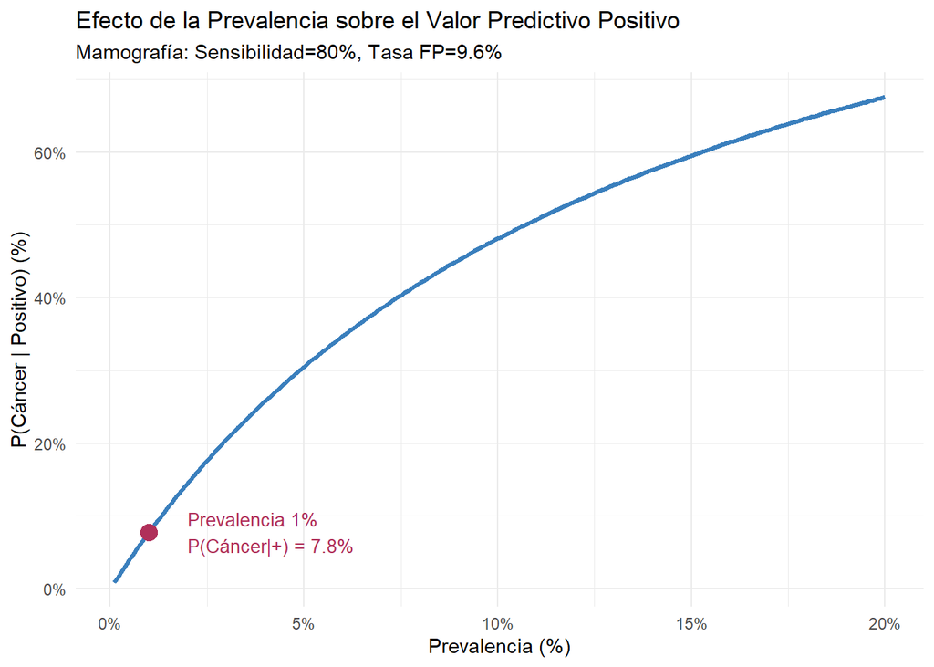

```r
# Visualización: cómo cambia la posterior con distintas prevalencias
library(ggplot2)
prevalencias <- seq(0.001, 0.20, 0.001)
post_cancer <- sapply(prevalencias, function(p) {
  conj <- c(sensibilidad * p, falso_pos * (1 - p))
  conj[1] / sum(conj)
})

df_prev <- data.frame(prevalencia = prevalencias, posterior = post_cancer)

ggplot(df_prev, aes(x = prevalencia * 100, y = posterior * 100)) +
  geom_line(color = "#3a7fbd", linewidth = 1.2) +
  geom_point(data = data.frame(x = 1, y = posterior[1] * 100),
             aes(x = x, y = y), color = "#b0305a", size = 4) +
  annotate("text", x = 2, y = posterior[1] * 100,
           label = paste0("Prevalencia 1%\nP(Cáncer|+) = ",
                           round(posterior[1] * 100, 1), "%"),
           hjust = 0, color = "#b0305a", size = 3.5) +
  labs(title = "Efecto de la Prevalencia sobre el Valor Predictivo Positivo",
       subtitle = "Mamografía: Sensibilidad=80%, Tasa FP=9.6%",
       x = "Prevalencia (%)", y = "P(Cáncer | Positivo) (%)") +
  theme_minimal() +
  scale_x_continuous(labels = function(x) paste0(x, "%")) +
  scale_y_continuous(labels = function(x) paste0(x, "%"))
```

**Resultados principales**

Probabilidad previa de cáncer: 1%

Probabilidad posterior dado resultado positivo: ≈ 7.8%

**Interpretación**

Aunque la prueba diagnóstica presenta buena sensibilidad (80%), el bajo nivel de prevalencia provoca que la probabilidad real de padecer cáncer, incluso con resultado positivo, sea relativamente baja.

Esto se debe a la presencia de falsos positivos (9.6%), lo que afecta significativamente el valor predictivo positivo.

**Conclusión y decisión**

Un resultado positivo no es suficiente para confirmar la enfermedad. Se recomienda:

Realizar pruebas confirmatorias adicionales.

Evitar decisiones médicas invasivas basadas en un único resultado.

Insight clave

La prevalencia de la enfermedad es un factor determinante en la interpretación de pruebas diagnósticas.